# Praca domowa 1

Karol Pysiak

October 14, 2018

Praca przygotowana przeze mnie jest na podstawie danych załączonych w artykule [Three reasons some countries are far more unequal than others](http://www.https://theconversation.com/three-reasons-some-countries-are-far-more-unequal-than-others-103638). Mój wykres został utworzony na podstawie zamieszczonej w tym artykule grafiki.

Dane pochodzą z World Wealth and Income Database. Opisują one jaki procentowy udział w łącznym zysku wszystkich obywateli ma 1% najbogatszych osób w państwie. Dane zostały obliczone przed opodatkownaiem, a zbierane były w dwóch okresach: 1976-80 oraz 2010-14. Przedstawione liczby są to średnie ze wszystkich lat danego okresu w danym państwie.

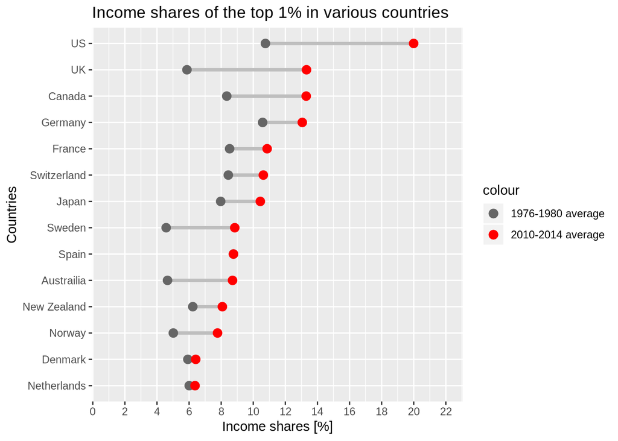

Wykres kładzie nacisk na rozłożenie przychodów w latach 2010-2014, gdyż oś Y została w taki sposób posortowana. Dzięki temu możemy odczytać, że największe dysproporcje panują ostatnio w USA, a w Dani oraz Holandii są one bardzo małe. Bardzo dobrze jest tutaj widoczna zmiana tego parametru na przestrzeni lat. Stany nie zaskakują nas w tym miejscu, ale za to Zjednoczone Królestwo zaliczyło w tych latach duży w porównaniu do innych państw wzrost dysproporcji zysku. Ponownie w przypadku Dani i Holandii otrzymujemy małe liczby, gdyż zwiększenie udziału 1% najbogatszych ludzi było minimalne. Najmniej intuicyjna, ale ciągle czytelna jest część wykresu poświęcona latom 1976-80. Możemy stąd odczytać, że największe dysproporcje panowały w Niemczech i USA, a najmniejsze w Szwecji i Australii, jednakże odczytanie tego nie było już aż tak wygodne.